# Reference18 UMI50：重叠组成-neighborhood患者级疾病比较

Rendered 2026-10-11T18:33:42 | Analysis directory: D:\Lung ST\codex agent\stereo_seq\stereo_seq\results\reanalysis\REFERENCE18_UMI50_OVERLAPPING_COMPOSITION_NEIGHBORHOODS_20261011_182142_attempt2

**主要结论：**在冻结的UMI≥50、21患者、Reference18数据上， 没有组成-neighborhood同时通过HC3全局FDR、chip内置换全局FDR、深度方向一致性和逐患者剔除标准。 因此本分析未检出HC、IPF和SSc-ILD之间受统计支持、可重复的局部细胞组成差异；这不等于证明差异绝对不存在。

## 1. 这一步究竟分析了什么？

每个Bin50先继承既有的50 μm物理空间邻域：把中心bin及其附近bin的RCTD Reference18权重汇总为18维组成。 这一步没有重跑RCTD，也没有重新改变物理空间邻域。

随后把126,449个局部空间邻域放进共同的18维组成空间。这里不再用K=3、4、5或8强迫分群， 而是用彼此可以重叠的近邻集合表示组成相似区域。因此，一个bin可以参与多个组成-neighborhood， 连续的组成梯度不会被强制切成互斥类别。

- 疾病盲参考：每位患者抽取500个bin，共10,500个。
- 精炼锚点：679个；主尺度为每个锚点最近的500个bin。
- 可比较性过滤后：262个neighborhood，共786项疾病对比。
- 统计单位：患者，而不是bin；模型校正chip，疾病标签在chip内置换10,000次。

## 2. 输入与患者支持图怎么读？

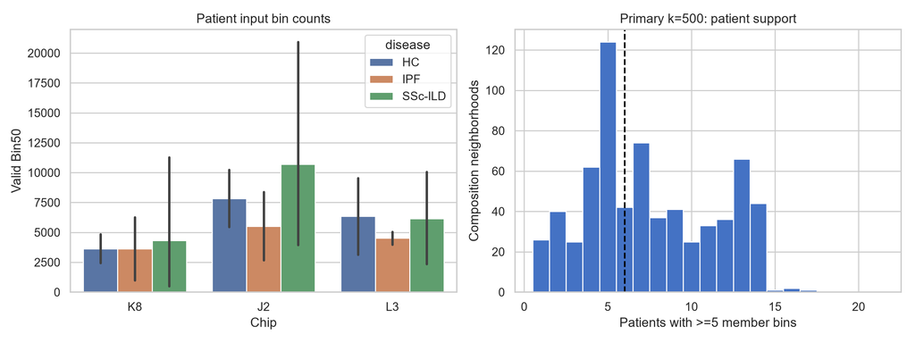

**左图：**柱高是各chip、各疾病组患者可用Bin50数量的均值，黑线是绘图默认的组均值置信区间。 它说明三张chip的有效bin数量不同，患者之间也相差很大，所以不能把126,449个bin当成126,449个独立样本。 本分析先转为患者比例，再以21位患者进行推断。

**右图：**横轴表示一个组成-neighborhood在多少位患者中至少包含5个bin。 虚线位于6，是最低患者支持门槛。许多锚点只出现在少数患者，因此被排除； 主尺度679个锚点中有262个进入正式疾病检验。

**注意：**“k=500”不是K-means的K，也不是500个患者； 它指每个重叠组成-neighborhood由组成空间中最近的500个Bin50构成。

### 每张chip的疾病构成

| disease | chip_short | HC | IPF | SSc-ILD |
| --- | --- | --- | --- | --- |
|  | J2 | 2 | 2 | 3 |
|  | K8 | 2 | 2 | 3 |
|  | L3 | 2 | 2 | 3 |

三张chip均为HC 2、IPF 2、SSc-ILD 3，故疾病与chip不是完全混杂，模型可以同时估计chip和疾病效应。

## 3. 疾病效应图怎么读？

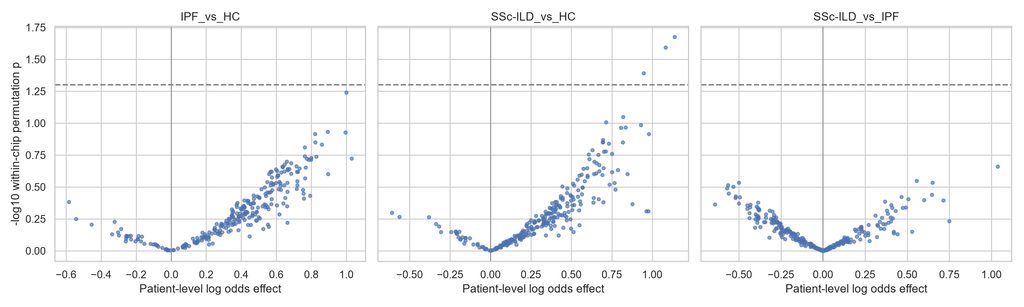

每个点代表一个通过支持过滤的组成-neighborhood。横轴是患者级log-odds效应：右侧表示前一个疾病组中更丰富， 左侧表示更少；纵轴是chip内置换P值的−log10。虚线对应未经多重校正的P=0.05。

- IPF vs HC：没有点达到未经校正的置换P<0.05。
- SSc-ILD vs HC：少数点越过虚线，但经过786项全局多重校正后全部消失。
- SSc-ILD vs IPF：没有明显候选。

最小置换P来自CN0423的SSc-ILD_vs_HC： OR=3.12，置换P=0.0211， 全局置换FDR=0.999。它是探索性趋势，不是阳性疾病结果。

## 4. 热图表示什么？

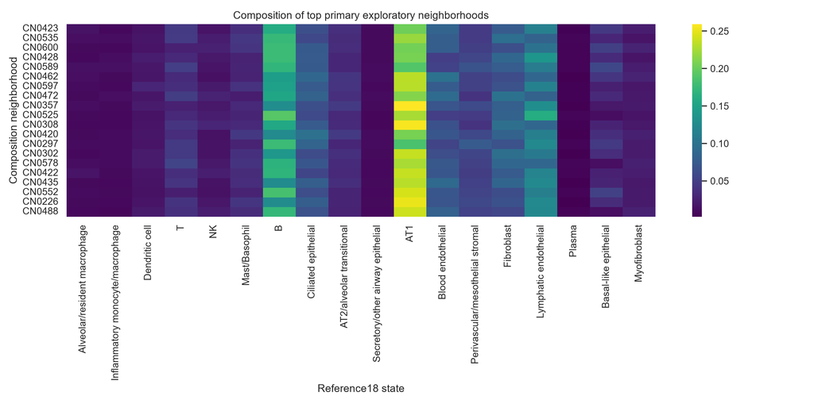

行是按未经校正置换P排序靠前的探索性neighborhood，列是Reference18状态，颜色表示该状态在neighborhood中的平均RCTD组成。 这些模式整体以AT1、B、淋巴内皮，并伴不同程度T、血管/基质或其他免疫成分为主。

## 5. 我们得到了什么？

1. **完成了方法缺口：**以前UMI50只做过离散K聚类；现在完成了不依赖K的、多变量、重叠neighborhood疾病比较。
2. **得到可靠的阴性主结论：**HC、IPF、SSc-ILD之间没有通过预设稳健性标准的组成-neighborhood。
3. **排除了“只是K选错”的主要担忧：**300和800近邻敏感性与500近邻的效应Spearman相关为 0.87–0.94，方向一致率为 88%–97%。
4. **保留了少量探索线索：**主要是SSc-ILD相对HC升高的AT1/B/淋巴内皮混合组成，但不能升级为疾病niche。

## 6. 最靠前的探索性结果

| Neighborhood | Contrast | Odds ratio | HC3 P | Permutation P | Global permutation FDR | Depth-adjusted P | LOO direction fraction | Top mean states |
| --- | --- | --- | --- | --- | --- | --- | --- | --- |
| CN0423 | SSc-ILD_vs_HC | 3.1207 | 0.0242 | 0.0211 | 0.9989 | 0.1792 | 1.0000 | AT1;B;Lymphatic endothelial |
| CN0535 | SSc-ILD_vs_HC | 2.9515 | 0.0312 | 0.0255 | 0.9989 | 0.1813 | 1.0000 | AT1;B;Fibroblast |
| CN0600 | SSc-ILD_vs_HC | 2.5782 | 0.0718 | 0.0405 | 0.9989 | 0.3285 | 1.0000 | AT1;B;Lymphatic endothelial |
| CN0535 | IPF_vs_HC | 2.7158 | 0.0670 | 0.0575 | 0.9989 | 0.0397 | 1.0000 | AT1;B;Fibroblast |
| CN0428 | SSc-ILD_vs_HC | 2.2681 | 0.1306 | 0.0893 | 0.9989 | 0.4155 | 1.0000 | AT1;B;Lymphatic endothelial |
| CN0589 | SSc-ILD_vs_HC | 2.0411 | 0.1124 | 0.0983 | 0.9989 | 0.4232 | 1.0000 | AT1;B;Lymphatic endothelial |
| CN0462 | SSc-ILD_vs_HC | 2.5312 | 0.1492 | 0.1034 | 0.9989 | 0.3233 | 1.0000 | AT1;B;Blood endothelial |
| CN0597 | SSc-ILD_vs_HC | 2.3038 | 0.1384 | 0.1083 | 0.9989 | 0.3992 | 1.0000 | AT1;B;Lymphatic endothelial |
| CN0472 | SSc-ILD_vs_HC | 2.2382 | 0.1743 | 0.1085 | 0.9989 | 0.4713 | 1.0000 | AT1;B;Fibroblast |
| CN0357 | IPF_vs_HC | 2.4440 | 0.1578 | 0.1168 | 0.9989 | 0.1852 | 1.0000 | AT1;Lymphatic endothelial;B |

## 7. 方法锁定与验证

### 关键参数

| parameter | value |
| --- | --- |
| input_h5 | D:\Lung ST\codex agent\stereo_seq\stereo_seq\results\reanalysis\REFERENCE18_UMI50_VOLTRON_NICHE_ASSAY_20260929_000834_attempt3\02_REFERENCE18_UMI50_NICHE_ASSAY_50_100UM.h5 |
| input_sha256 | 30ab575242744b62b8049791c68fa406406cd5b9c3eea700b2eb1d289814033b |
| spatial_radius_um | 50 |
| center_bin | included (inherited frozen assay) |
| transform | exact frozen-workflow VoltRon zero-safe CLR |
| reference_per_patient | 500 |
| reference_k | 100 |
| anchor_proportion | 0.1 |
| primary_membership_k | 500 |
| support_filter | >=5 bins in >=6 patients; >=2 patients in >=2 chips; max patient fraction <=0.8 |
| primary_model | HC3 OLS on corrected-logit patient fraction: chip + disease |
| permutations | 10000 disease-label permutations within chip |
| multiple_testing | BH within contrast and globally across all three contrasts |
| supported_finding_rule | global HC3 FDR<0.05 AND global permutation FDR<0.05 AND depth-adjusted same direction AND LOO direction fraction>=0.80 |
| seed | 20261011 |

### 自动验证

| check | pass | observed |
| --- | --- | --- |
| input_shape_126449_by_18 | True | (126449, 18) |
| composition_finite | True | all finite |
| composition_rows_sum_to_one | True | 0.9999999 |
| twenty_one_patients | True | 21 |
| balanced_chip_disease_design | True | {"HC":{"Y40102K8":2,"Y40105J2":2,"Y40105L3":2},"IPF":{"Y40102K8":2,"Y40105J2":2,"Y40105L3":2},"SSc-ILD":{"Y40102K8":3,"Y40105J2":3,"Y40105L3":3}} |
| reference_size_10500 | True | 10500 |
| anchors_after_refinement | True | 679 |
| primary_neighborhood_exact_size | True | 500 |
| primary_tested_neighborhoods | True | 262 |
| permutation_p_resolution | True | 0.021097890210978902 |
| finite_primary_effects | True | all finite |
| membership_has_overlap | True | 77 |

所有验证项均为PASS。第一次运行目录在写图时因交互命令超时而中断且没有完成标记； 本报告只使用带`COMPLETE.ok`的`attempt2`目录。

## 8. 环境信息

```
{
  "python": "3.12.14 (main, Aug 25 2026, 14:01:42) [MSC v.1944 64 bit (AMD64)]",
  "platform": "Windows-11-10.0.26200-SP0",
  "numpy": "2.4.6",
  "pandas": "3.0.5"
}
report_python: 3.12.14 (main, Aug 25 2026, 14:01:42) [MSC v.1944 64 bit (AMD64)]
report_platform: Windows-11-10.0.26200-SP0
```